# Taller 3

Santiago Aillón, Santiago Arévalo, Juan José Caballero y Laura Ortiz

2022-09-01

### *1.* Find the maximum likelihood estimates of the 2 × 1 mean vector *μ* and the 2 × 2 covariance matrix *Σ* based on the random sample

$\textbf{X}= \begin{bmatrix} 3 & 6\\ 4 & 4\\ 5 & 7\\ 4 & 7\\ \end{bmatrix}$

### from a bivariate normal population.

```r
X = cbind(c(3, 4, 5, 4), c(6, 4, 7, 7))
X1 = data.frame(X)
X1_mu = colMeans(X1)
X1_mu
```

```
## X1 X2
##  4  6
```

```r
X1_sigma = cov(X1) * (nrow(X1) - 1) / nrow(X1)
X1_sigma
```

```
##      X1   X2
## X1 0.50 0.25
## X2 0.25 1.50
```

### *2.* Using the data:

$\textbf{X}= \begin{bmatrix} 2 & 12\\ 8 & 9\\ 6 & 9\\ 8 & 10\\ \end{bmatrix}$

```r
X2 = cbind(c(2, 8, 6, 8), c(12, 9, 9, 10))
X2 = data.frame(X2)
```

#### *a.* Evaluate *T<sup>2</sup>*, for testing $H_0$ *: μ’ = [7, 11]*, using the data.

```r
mu0 = c(7, 11)
mu = colMeans(X2)
n = nrow(X2)

S = cov(X2)

t2 = n * rbind(mu - mu0) %*% solve(S) %*% t(rbind(mu - mu0))
t2
```

```
##          [,1]
## [1,] 13.63636
```

#### *b.* Specify the distribution of *T<sup>2</sup>* for the situation in (a).

T<sup>2</sup> debe seguir una distribución $\frac{p(n - 1)}{n - p} F_{p, \; n - p} = 3F_{2, 2}$ grados de libertad. Es decir T<sup>2</sup> ~ $3F_{2, 2}$

#### *c.* Using (a) and (b), test $H_0$ at the *α = .05* level. What conclusion do you reach?

```r
n = nrow(X2)
p = ncol(X2)
alpha = 0.05

t2_val = qf(1 - alpha, p, n - p, lower.tail = FALSE) * (p*(n - 1)) / (n - p)
t2_val
```

```
## [1] 0.1578947
```

```r
t2 > t2_val
```

```
##      [,1]
## [1,] TRUE
```

### *3.* Harry Roberts, a naturalist for the Alaska Fish and Game department, studies grizzly bears with the goal of maintaining a healthy population. Measurements on *n = 61* bears provided the following summary statistics:

| Variable | Weight(kg) | Body length(cm) | Neck | Girth | Head length | Head width |
| --- | --- | --- | --- | --- | --- | --- |
| Sample mean x̄ | 95.52 | 164.38 | 55.69 | 93.39 | 17.98 | 31.13 |

$\textbf{Covariance matrix S}= \begin{bmatrix} 3266.46 & 1343.97 & 731.54 & 1175.50 & 162.68 & 238.37\\ 1343.97 & 721.91 & 324.25 & 537.35 & 80.17 & 117.73\\ 731.54 & 324.25 & 179.28 & 281.17 & 39.15 & 56.80\\ 1175.50 & 537.35 & 281.17 & 474.98 & 63.73 & 94.85\\ 162.68 & 80.17 & 39.15 & 63.73 & 9.95 & 13.88\\ 238.37 & 117.73 & 56.80 & 94.85 & 13.88 & 21.26\\ \end{bmatrix}$

```r
covS = matrix(c(3266.46, 1343.97, 731.54, 1175.50, 162.68, 238.37,
                1343.97, 721.91, 324.25, 537.35, 80.17, 117.73,
                731.54, 324.25, 179.28, 281.17, 39.15, 56.80,
                1175.50, 537.35, 281.17, 474.98, 63.73, 94.85,
                162.68, 80.17, 39.15, 63.73, 9.95, 13.88,
                238.37, 117.73, 56.80, 94.85, 13.88, 21.26), byrow=FALSE, ncol=6)

x_bar = matrix(c(95.52, 164.38, 55.69, 93.39, 17.98, 31.13), byrow=FALSE, ncol=6)

p = ncol(covS)
n = 61
```

#### *a.* Obtain the large sample 95% simultaneous confidence intervals for the six population mean body measurements.

El intervalo de confianza simultáneo es:

$a' \bar{X} \pm \sqrt{\frac{p(n - 1)}{n(n - p)} F_{p, n - p} (\alpha) a'Sa}$

Teniendo en cuenta que n es grande, los intervalos de confianza simultáneos de una muestra grande para seis medidas corporales medias de la población, estaran dados por:

$\bar{x_1} \pm \sqrt{\frac{p(n - 1)}{(n - p)} F_{p, n - p} (\alpha)} \sqrt{\frac{S_{kk}}{n}}$

```r
a = matrix(c(1, 0, 0, 0, 0, 0,
             0, 1, 0, 0, 0, 0,
             0, 0, 1, 0, 0, 0,
             0, 0, 0, 1, 0, 0,
             0, 0, 0, 0, 1, 0,
             0, 0, 0, 0, 0, 1), byrow=FALSE, ncol=6)

alpha = 0.05

upr_interval = c()
lwr_interval = c()

for (i in 1:nrow(a)){

  upr_interval = append(upr_interval, x_bar[i] + sqrt((p*(n - 1))/(n*(n - p)) * qf(1 - alpha, p, n - p)*t(a[i,]) %*% covS %*% a[i,]))

  lwr_interval = append(lwr_interval, x_bar[i] - sqrt((p*(n - 1))/(n*(n - p)) * qf(1 - alpha, p, n - p)*t(a[i,]) %*% covS %*% a[i,]))

}

upr_interval
```

```
## [1] 123.71901 177.63674  62.29634 104.14308  19.53635  33.40498
```

```r
lwr_interval
```

```
## [1]  67.32099 151.12326  49.08366  82.63692  16.42365  28.85502
```

Los intervalos simultáneos fueron:

67.32099 ≤ $\mu_1$ ≤ 123.71901  
151.12326 ≤ $\mu_2$ ≤ 177.63674  
49.08366 ≤ $\mu_3$ ≤ 62.29634  
82.63692 ≤ $\mu_4$ ≤ 104.14308  
16.42365 ≤ $\mu_5$ ≤ 19.53635  
28.85502 ≤ $\mu_6$ ≤ 33.40498

#### *b.* Obtain the large sample 95% confidence ellipse for mean weight and mean girth.

```r
x1 = c(3266.46, 1343.97, 731.54, 1175.50, 162.68, 238.37)
x2 = c(1343.97, 721.91, 324.25, 537.35, 80.17, 117.73)
x3 = c(731.54, 324.25, 179.28, 281.17, 39.15, 56.80)
x4 = c(1175.50, 537.35, 281.17, 474.98, 63.73, 94.85)
x5 = c(162.68, 80.17, 39.15, 63.73, 9.95, 13.88)
x6 = c(238.37, 117.73, 56.80, 94.85, 13.88, 21.26)
S = data.frame(x1, x2, x3, x4, x5, x6)
S
```

```
##        x1      x2     x3      x4     x5     x6
## 1 3266.46 1343.97 731.54 1175.50 162.68 238.37
## 2 1343.97  721.91 324.25  537.35  80.17 117.73
## 3  731.54  324.25 179.28  281.17  39.15  56.80
## 4 1175.50  537.35 281.17  474.98  63.73  94.85
## 5  162.68   80.17  39.15   63.73   9.95  13.88
## 6  238.37  117.73  56.80   94.85  13.88  21.26
```

```r
sub_s = matrix( c(covS[1,1], covS[4,1], covS[1,4], covS[4,4]), ncol = 2, nrow = 2)
eigen_decomp = eigen(sub_s)

#atan(y/x) = theta
angle = atan(eigen_decomp$vectors[2,1]/eigen_decomp$vectors[1,1])
angle
```

```
## [1] 0.3499758
```

```r
install.packages("plotrix")
library(plotrix)

#media del peso y de la cintura
means = c(95.52, 93.39)
n = 61
p = 6
alpha = 0.05

len1 <- sqrt( eigen_decomp$values[1] )*sqrt( (p*(n-1))/(n*(n-p))* qf(1-alpha,p,n-p) )
len2 <- sqrt( eigen_decomp$values[2] )*sqrt( (p*(n-1))/(n*(n-p))*qf(1-alpha,p,n-p) )
lengths <- c(len1, len2)
lengths
```

```
## [1] 29.993897  3.343506
```

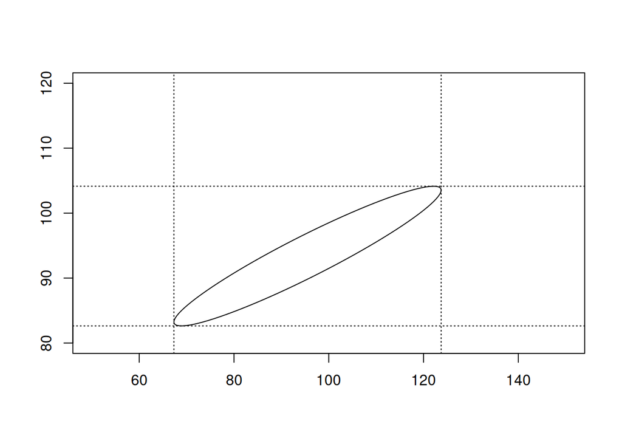

```r
plot(0, pch='',ylab='',xlab='',xlim=c(50,150),ylim=c(80,120))
draw.ellipse(x=means[1],y=means[2], a=lengths[1], b=lengths[2], angle=angle,deg=FALSE)

abline(v=lwr_interval[1],lty=3);abline(v=upr_interval[1],lty=3)
abline(h=lwr_interval[4],lty=3);abline(h=upr_interval[4],lty=3)
```

#### *c.* Obtain the 95% Bonferroni confidence intervals for the six means in Part (a).

#### *d.* Refer to Part (b). Construct the 95% Bonferroni confidence rectangle for the mean weight and mean girth using *m = 6*. Compare this rectangle with the confidence ellipse in Part (b).